# Clustering (Part II)

## Cutting Dendograms

- A weakness of hierarchical clustering is the difficulty in choosing the number of clusters (where to cut the dendrogram)
  - Often, the number of clusters is determined by visual inspection
- Some methods, like the average silhouette distance, are still possible but there is less consensus on how to use them
- `fviz_dend` allows dendrograms to be cut by specifying a number of clusters “k” or by specifying a height “h”

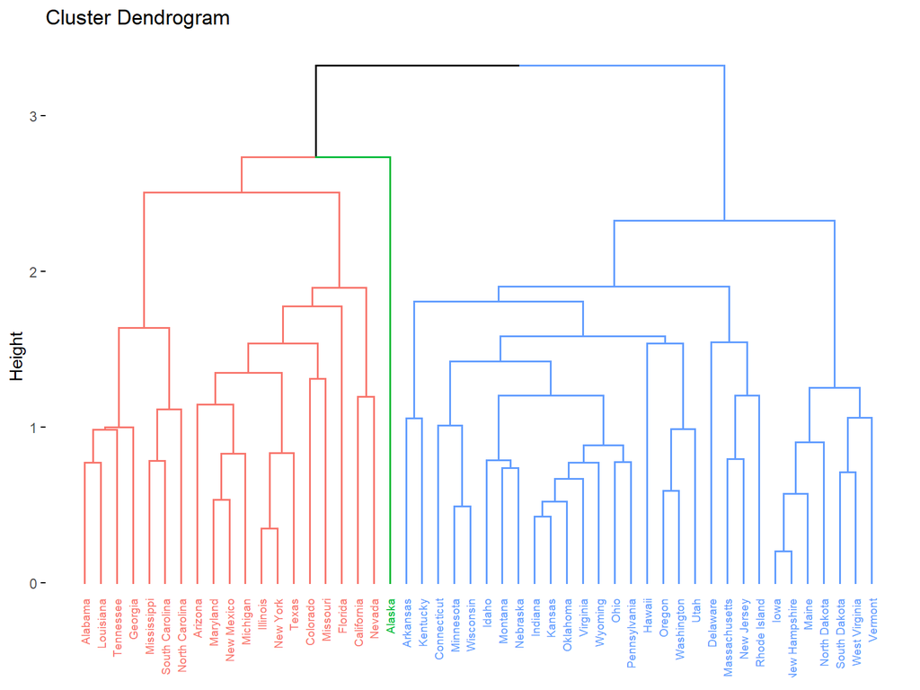

```r
fviz_dend(ag, k = 3, cex = 0.5)
```

```
##   cluster size ave.sil.width
## 1       1    7          0.44
## 2       2    1          0.00
## 3       3   12          0.32
## 4       4   30          0.37
```

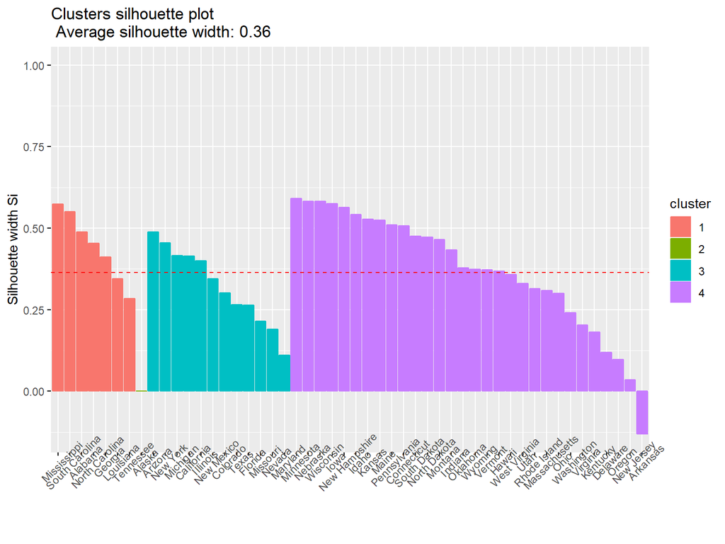

```r
## cutree cuts a dendrogram
sil_ag <- silhouette(cutree(ag, 4), dist = d)
rownames(sil_ag) <- rownames(USArrests)
fviz_silhouette(sil_ag, label = TRUE)
```

## Clustering with Categorical Variables?

- Clustering works well for numeric data because distance is well-defined
- We can still apply clustering to categorical (or mixed numeric and categorical) data, but we need to define a more flexible distance measure
- One such metric is **Gower Distance**, the idea is to use a distance metric that work well for type of variable under consideration, and re-scale it to range from 0 to 1 so that all variable types are on a level playing field

## Using Gower Distance

- Gower distance be used to construct a distance matrix, allowing it to be used with any clustering method that relies upon a dissimilarity (distance) matrix, such as:
  - PAM
  - DIANA
  - AGNES
  - Hclust
  - DBSCAN (not presented, but also popular)
- We will apply Gower distance (and then clustering) to the “animals” data set

|  | Warm-blooded | Can_fly | Vertebrate | Endangered | Lives_in_groups | Has_hair |
| --- | --- | --- | --- | --- | --- | --- |
| ant | No | No | No | No | Yes | No |
| bee | No | Yes | No | No | Yes | Yes |
| cat | Yes | No | Yes | No | No | Yes |
| cpl | No | No | No | No | No | Yes |
| chi | Yes | No | Yes | Yes | Yes | Yes |
| cow | Yes | No | Yes | No | Yes | Yes |
| duc | Yes | Yes | Yes | No | Yes | No |
| eag | Yes | Yes | Yes | Yes | No | No |
| ele | Yes | No | Yes | Yes | Yes | No |
| fly | No | Yes | No | No | No | No |
| fro | No | No | Yes | Yes | NA | No |
| her | No | No | Yes | No | Yes | No |
| lio | Yes | No | Yes | NA | Yes | Yes |
| liz | No | No | Yes | No | No | No |
| lob | No | No | No | No | NA | No |
| man | Yes | No | Yes | Yes | Yes | Yes |
| rab | Yes | No | Yes | No | Yes | Yes |
| sal | No | No | Yes | No | NA | No |
| spi | No | No | No | NA | No | Yes |
| wha | Yes | No | Yes | Yes | Yes | No |

## Using Gower Distance - Visualizing the Distance Matrix

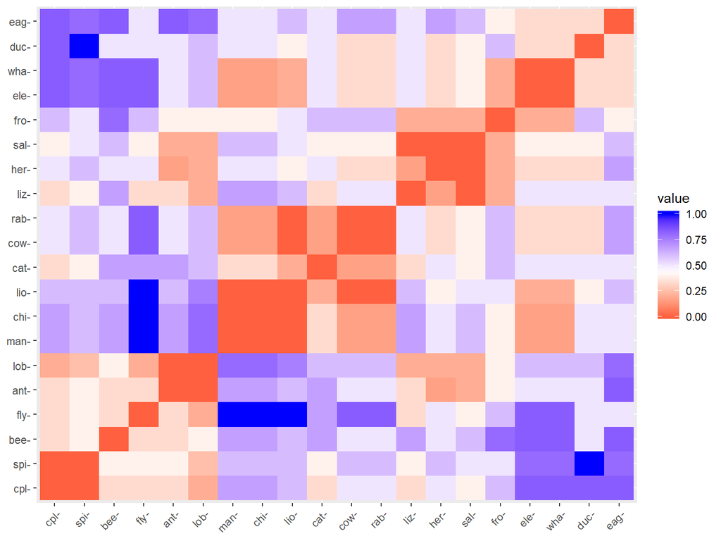

```r
D <- daisy(as.data.frame(animals), metric = "gower")
fviz_dist(D)
```

## Using Gower Distance - Examples

- An advantage of hierarchal clustering is that it’s visuals are more accommodating of categorical data

```
##   cluster size ave.sil.width
## 1       1    9          0.38
## 2       2    6          0.70
## 3       3    5          0.22
```

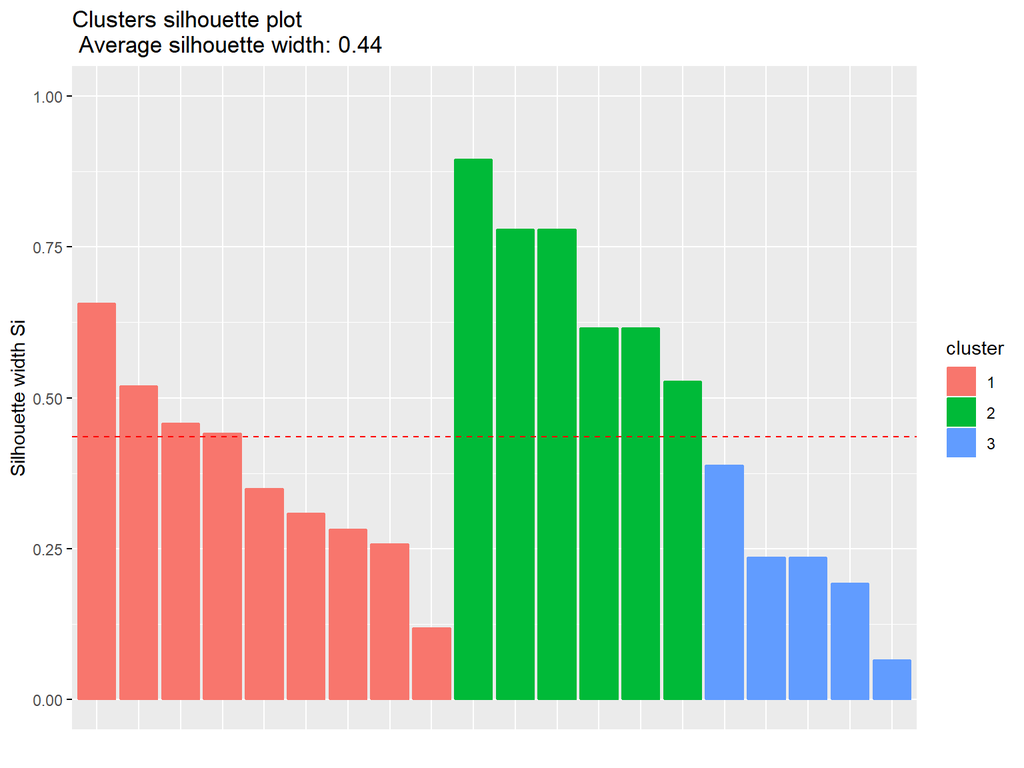

```r
## Pam Clustering, not much to visualize other than silhouettes
pm <- pam(D, k = 3)
fviz_silhouette(silhouette(pm))
```

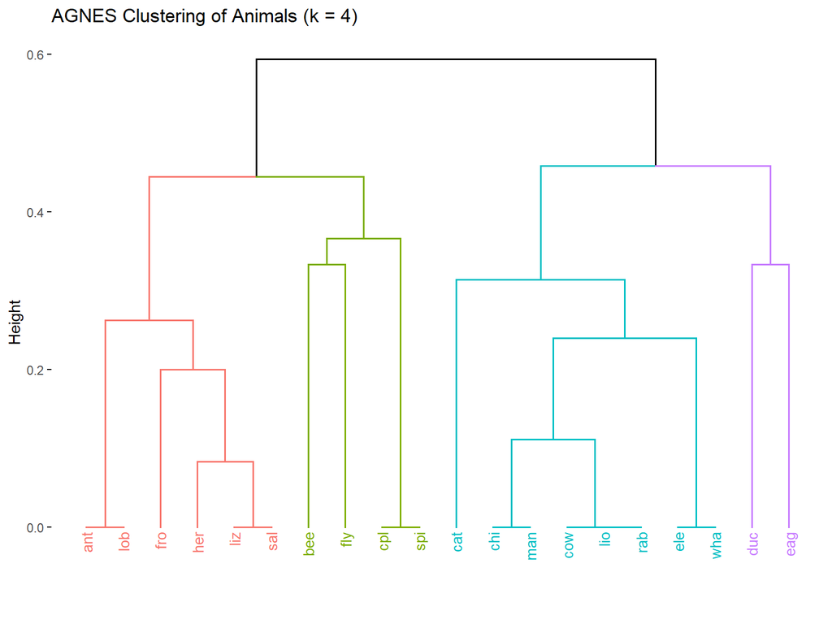

```r
## Hierarchal Clustering
ag <- agnes(D)
fviz_dend(ag, cex = 0.7, k = 4) + labs(title = "AGNES Clustering of Animals (k = 4)")
```